# Homework ASM (SoSe 2021) – Week 6

Marc Blauert

2021-05-19

#### Tasks description (McElreath Ch. 5.5, Ex. 5H4, using brms)

Here is an open practice problem to engage your imagination. In the divorce data, States in the southern United States have many of the highest divorce rates. Add the South indicator variable to the analysis. First, draw one or more DAGs that represent your ideas for how Southern American culture might influence any of the other three variables (D, M or A). Then list the testable implications of your DAGs, if there are any, and fit one or more models to evaluate the implications. What do you think the influence of “Southerness” is?

### Part 1: Data wrangling

First, I load the data. To prepare it for the analysis, I fist standardize the variables on divorce rate, marriage rate and median age of marriage as it was done in the book chapter example. Furthermore, I also create an index variable for state type either being a Southern state or a non-Southern state.

```r
# Loading the data:
data(WaffleDivorce, package = "rethinking")
d <- WaffleDivorce
rm(WaffleDivorce)

# Standardizing the variables for divorce rate (D), marriage rate (M), and median age at marriage (A):
d <-
  d %>%
  mutate(D = (Divorce - mean(Divorce)) / sd(Divorce)) %>%
  mutate(M = (Marriage - mean(Marriage)) / sd(Marriage)) %>%
  mutate(A = (MedianAgeMarriage - mean(MedianAgeMarriage)) / sd(MedianAgeMarriage))

# Creating a index variable for state type (S):
d <-
  d %>%
  mutate(S = ifelse(South == 1, 2, 1)) %>%
  mutate(S = factor(S))

levels(d$S) <- c("Non-Southern state", "Southern state")

str(d)
```

```
## 'data.frame':    50 obs. of  17 variables:
##  $ Location         : Factor w/ 50 levels "Alabama","Alaska",..: 1 2 3 4 5 6 7 8 9 10 ...
##  $ Loc              : Factor w/ 50 levels "AK","AL","AR",..: 2 1 4 3 5 6 7 9 8 10 ...
##  $ Population       : num  4.78 0.71 6.33 2.92 37.25 ...
##  $ MedianAgeMarriage: num  25.3 25.2 25.8 24.3 26.8 25.7 27.6 26.6 29.7 26.4 ...
##  $ Marriage         : num  20.2 26 20.3 26.4 19.1 23.5 17.1 23.1 17.7 17 ...
##  $ Marriage.SE      : num  1.27 2.93 0.98 1.7 0.39 1.24 1.06 2.89 2.53 0.58 ...
##  $ Divorce          : num  12.7 12.5 10.8 13.5 8 11.6 6.7 8.9 6.3 8.5 ...
##  $ Divorce.SE       : num  0.79 2.05 0.74 1.22 0.24 0.94 0.77 1.39 1.89 0.32 ...
##  $ WaffleHouses     : int  128 0 18 41 0 11 0 3 0 133 ...
##  $ South            : int  1 0 0 1 0 0 0 0 0 1 ...
##  $ Slaves1860       : int  435080 0 0 111115 0 0 0 1798 0 61745 ...
##  $ Population1860   : int  964201 0 0 435450 379994 34277 460147 112216 75080 140424 ...
##  $ PropSlaves1860   : num  0.45 0 0 0.26 0 0 0 0.016 0 0.44 ...
##  $ D                : num  1.654 1.544 0.611 2.094 -0.927 ...
##  $ M                : num  0.0226 1.5498 0.049 1.6551 -0.267 ...
##  $ A                : num  -0.606 -0.687 -0.204 -1.41 0.6 ...
##  $ S                : Factor w/ 2 levels "Non-Southern state",..: 2 1 1 2 1 1 1 1 1 2 ...
```

```r
# Get some first summary statistics grouped by state type (S):
d %>%
  group_by(S) %>%
  summarise(avg_D = mean(D), avg_M = mean(M), avg_A = mean(A))
```

```
## # A tibble: 2 x 4
##   S                   avg_D   avg_M  avg_A
##   <fct>               <dbl>   <dbl>  <dbl>
## 1 Non-Southern state -0.213 -0.0505  0.153
## 2 Southern state      0.548  0.130  -0.394
```

### Part 2: Collecting ideas and drawing of DAG

Having prepared the data, I turn to developing an idea of how the inclusion of the index variable S = Southern (or non-Southern) state might affect the other variables in the model (D = divorce rate, M = marriage rate, and A = median age at marriage).

Here, I turn to the role of religious beliefs in Southern states across the different ethnic groups. In general, we know that Southern states are deeply religious. Much more so than the other non-Southern states of the United States. Commonly, large areas of the Southern states are also referred to as the “Bible Belt,” reflecting the deeply rooted role of the Baptist and Catholic faiths in this region. Given this knowledge of the important role of the Christian religion, I assume the following relationships between S and the other variables in the model:

- S to directly influence A –> Because of strong religious beliefs, I assume that people in the Southern states are more likely to marry at a younger age (premarital chastity, conservative views of relationships)
- S to directly influence D –> Similarly, it seems possible that people are quicker to choose marriage (regardless of their age) because it is seen as the right form of relationship for them. As a result, couples have not really tested their compatibility when they enter into marriage and are therefore more likely to divorce at some point. This effect may also work in the opposite direction, where religious beliefs prevent a couple from getting divorced.

Those two relationships are shown in the following DAG:

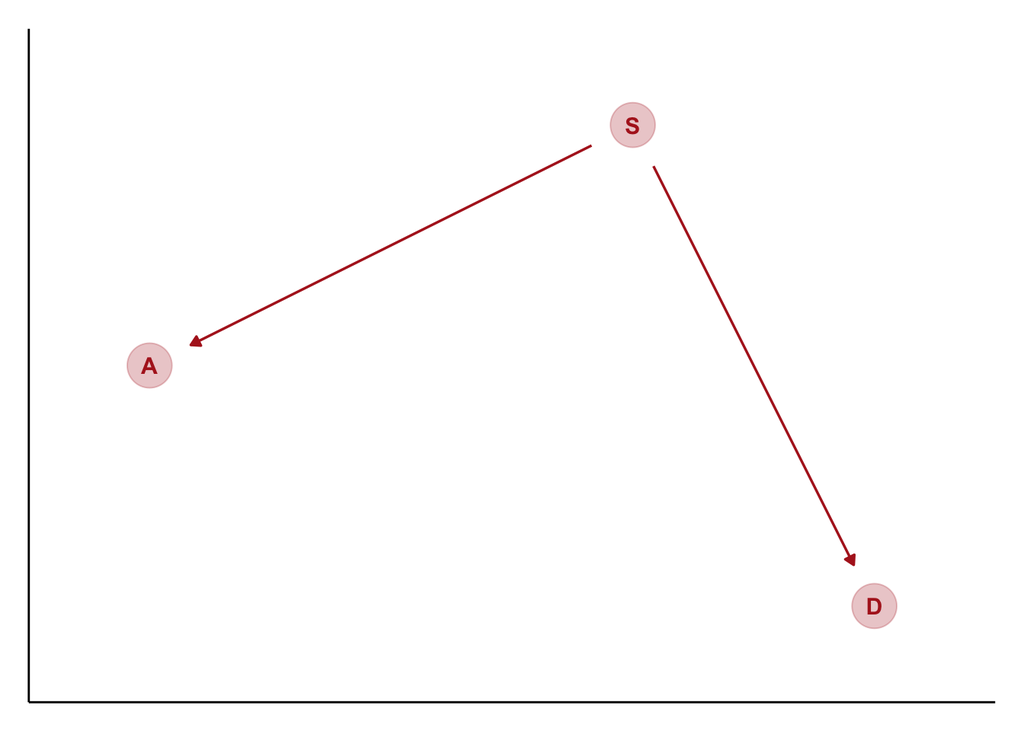

```r
# Specifying DAG function and coordinates:
gg_dag <- function(d) {

  d %>%
    ggplot(aes(x = x, y = y, xend = xend, yend = yend)) +
    geom_dag_point(color = "firebrick", alpha = 1/4, size = 10) +
    geom_dag_text(color = "firebrick") +
    geom_dag_edges(edge_color = "firebrick") +
    scale_x_continuous(NULL, breaks = NULL, expand = c(.1, .1)) +
    scale_y_continuous(NULL, breaks = NULL, expand = c(.1, .1)) +
    theme_plots() +
    theme(panel.grid = element_blank())

}

dag_coords <-
  tibble(name = c("A", "M", "S", "D"),
         x    = c(0.5, 0.5, 1.5, 2),
         y    = c(1.5, 0.5, 2, 1))

# Making the DAG:
dag1 <-
  dagify(A ~ S,
         D ~ S,
         coords = dag_coords) %>%
  gg_dag()

dag1
```

Supplementing the DAG with the relationships investigated in the Chapter by McElreath leads to the following more comprehensive DAG:

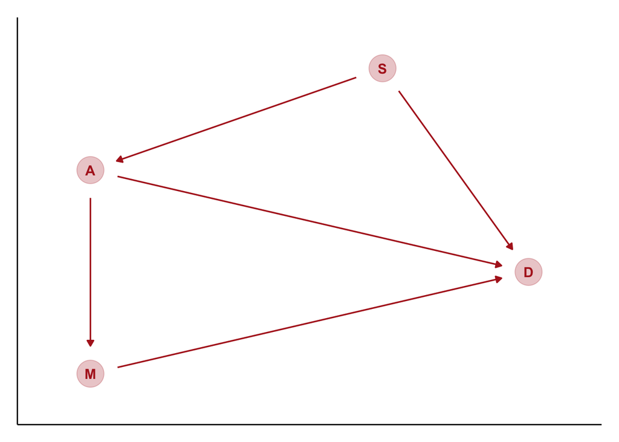

```r
dag2 <-
  dagify(M ~ A,
         A ~ S,
         D ~ A + M + S,
         coords = dag_coords) %>%
  gg_dag()

dag2
```

### Part 3: Regression analysis

To investigate if the DAGs drawn in the previous section have relevance, I will use three regressions. First, I will estimate two simple bivariate models to see if S exerts a direct influence on A and D (compare dag1). Then, in the second step, I will estimate a multiple linear regression (MLR) reflecting dag2 to see what effects remain/occur when the model simultaneously knows the other variables in the model.

#### Bivariate regression models

#### Model 1: Bivariate S –> A

Simple bivariate model with the state type index (S) as a predictor for median age at marriage (A):

$\text{A}_i\sim \operatorname{Normal}(\mu_i, \sigma)$  
$\mu_i= \alpha_{\text{S}[i]}$  
$\alpha_j \sim \operatorname{Normal}(0, 0.5) \qquad \text{for } j = 1 \; \& \; 2$  
$\sigma \sim \operatorname{Exponential}(1),$

```r
fit_biv_A <-
  brm(data = d,
      family = gaussian,
      A ~ 0 + S,
      prior = c(prior(normal(0, 0.5), class = b),
                prior(exponential(1), class = sigma)),
      iter = 2000, warmup = 1000, chains = 4, cores = 4,
      seed = 5,
      file = "fits/fit_biv_A")
```

```r
# plot(fit_biv_A)

summary(fit_biv_A)
```

```
##  Family: gaussian
##   Links: mu = identity; sigma = identity
## Formula: A ~ 0 + S
##    Data: d (Number of observations: 50)
## Samples: 4 chains, each with iter = 2000; warmup = 1000; thin = 1;
##          total post-warmup samples = 4000
##
## Population-Level Effects:
##                    Estimate Est.Error l-95% CI u-95% CI Rhat Bulk_ESS Tail_ESS
## SNonMSouthernState     0.14      0.16    -0.18     0.44 1.00     3859     3296
## SSouthernState        -0.31      0.23    -0.76     0.16 1.00     3708     3052
##
## Family Specific Parameters:
##       Estimate Est.Error l-95% CI u-95% CI Rhat Bulk_ESS Tail_ESS
## sigma     0.99      0.10     0.81     1.22 1.00     3052     2701
##
## Samples were drawn using sampling(NUTS). For each parameter, Bulk_ESS
## and Tail_ESS are effective sample size measures, and Rhat is the potential
## scale reduction factor on split chains (at convergence, Rhat = 1).
```

#### Model 2: Bivariate S –> D

Simple bivariate model with the state type index (S) as a predictor for divorce rate (D):

$\text{D}_i\sim \operatorname{Normal}(\mu_i, \sigma)$  
$\mu_i= \alpha_{\text{S}[i]}$  
$\alpha_j \sim \operatorname{Normal}(0, 0.5) \qquad \text{for } j = 1 \; \& \; 2$  
$\sigma \sim \operatorname{Exponential}(1),$

```r
fit_biv_D <-
  brm(data = d,
      family = gaussian,
      D ~ 0 + S,
      prior = c(prior(normal(0, 0.5), class = b),
                prior(exponential(1), class = sigma)),
      iter = 2000, warmup = 1000, chains = 4, cores = 4,
      seed = 5,
      file = "fits/fit_biv_D")
```

```r
# plot(fit_biv_D)

summary(fit_biv_D)
```

```
##  Family: gaussian
##   Links: mu = identity; sigma = identity
## Formula: D ~ 0 + S
##    Data: d (Number of observations: 50)
## Samples: 4 chains, each with iter = 2000; warmup = 1000; thin = 1;
##          total post-warmup samples = 4000
##
## Population-Level Effects:
##                    Estimate Est.Error l-95% CI u-95% CI Rhat Bulk_ESS Tail_ESS
## SNonMSouthernState    -0.19      0.16    -0.49     0.11 1.00     3931     2548
## SSouthernState         0.43      0.23    -0.02     0.88 1.00     3571     3052
##
## Family Specific Parameters:
##       Estimate Est.Error l-95% CI u-95% CI Rhat Bulk_ESS Tail_ESS
## sigma     0.97      0.10     0.80     1.18 1.00     3253     2822
##
## Samples were drawn using sampling(NUTS). For each parameter, Bulk_ESS
## and Tail_ESS are effective sample size measures, and Rhat is the potential
## scale reduction factor on split chains (at convergence, Rhat = 1).
```

After having estimated the two bivariate regression we are now able to plot the coefficients with 95% credible intervals:

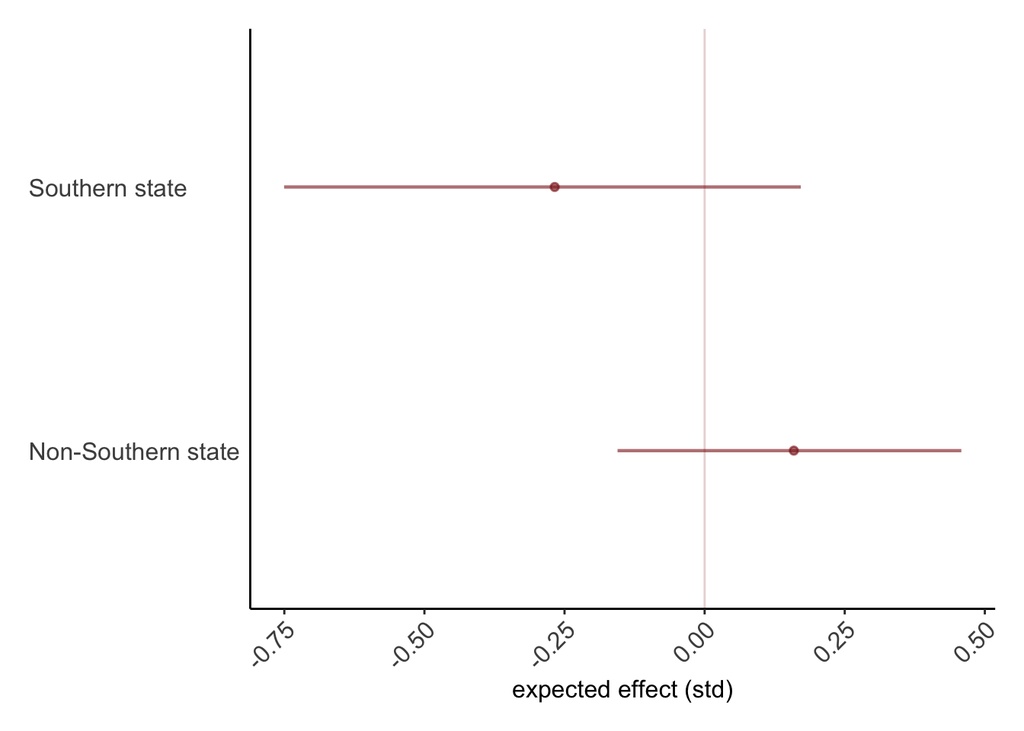

```r
# Specify function for coefficient plot
coef_plot <- function(post) {

post %>%
  select(starts_with("b")) %>%
  set_names(distinct(d, S) %>% arrange(S) %>% pull()) %>%
  pivot_longer(everything()) %>%

  ggplot(aes(x = value, y = name)) +
  geom_vline(xintercept = 0, color = "firebrick4", alpha = 0.2) +
  stat_pointinterval(point_interval = mode_hdi, .width = .95,
                     size = 2, color = "firebrick4", alpha = 0.6) +
  labs(x = "expected effect (std)",
       y = NULL) +
  theme_plots() +
  theme(axis.text.y = element_text(hjust = 0),
        axis.ticks.y = element_blank(),
        panel.grid = element_blank())

}

# Plot coefficients for bivariate regression S --> A
post_biv_A <- posterior_samples(fit_biv_A) %>%
  coef_plot()

post_biv_A
```

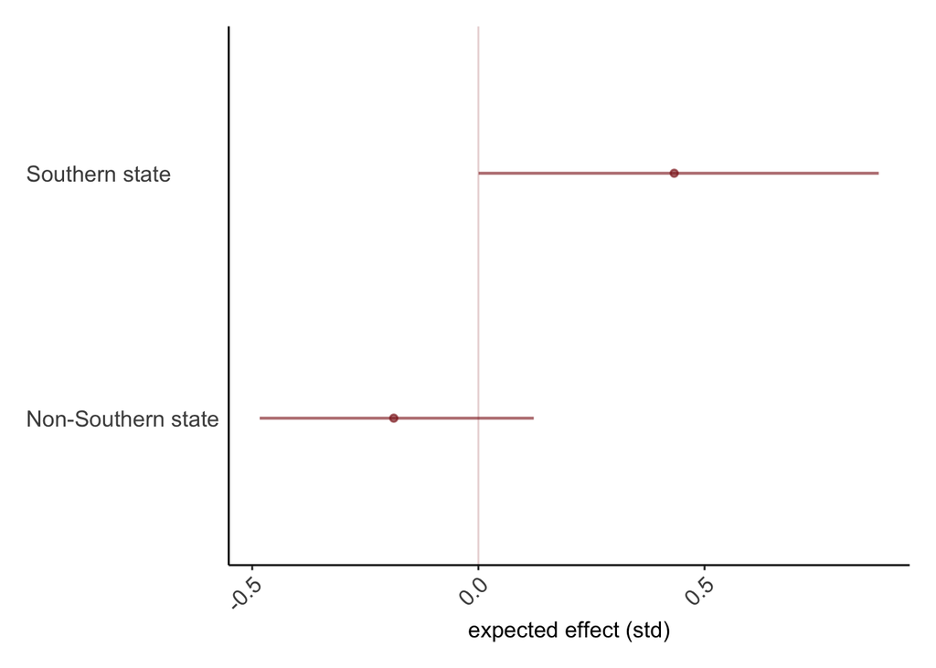

```r
# Plot coefficients for bivariate regression S --> D
post_biv_D <- posterior_samples(fit_biv_D) %>%
  coef_plot()

post_biv_D
```

In this second plot, we see the expected effects of using state type to predict divorce rates. According to the model, people in Southern states are more likely to divorce than those in non-Southern states. Given the hypothesized countervailing effects of religious beliefs on divorce rates, the relatively large difference between the two groups is surprising, suggesting that the hypothesized reasoning does not correspond to reality.

#### Multiple linear regression (MLR)

#### Model 3: MLR M, A, S –> D

To examine the three predictors of marriage rate, median age at marriage, and state type on divorce rate together, I use an MLR analysis. Since the index variable S only contains two groups, I simply extend the linear model used in the book by including it. This way the model computes one coefficient for the Southern states group which can be interpreted as the divergence to the non-Southern states as the second group (NOTE: I was not completely sure about this and how to best include S into the MLR model).

The model I use has the following specification:

$\text{D}_i\sim \operatorname{Normal}(\mu_i, \sigma)$  
$\mu_i= \alpha + \beta_1 \text{M}_i + \beta_2 \text{A}_i + \beta_3 \text{S}_i$  
$\alpha \sim \operatorname{Normal}(0, 0.2)$  
$\beta_1 \sim \operatorname{Normal}(0, 0.5)$  
$\beta_2 \sim \operatorname{Normal}(0, 0.5)$  
$\beta_3 \sim \operatorname{Normal}(0, 0.5)$  
$\sigma \sim \operatorname{Exponential}(1),$

```r
fit_mlr <-
  brm(data = d,
      family = gaussian,
      D ~ 1 + M + A + S,
      prior = c(prior(normal(0, 0.2), class = Intercept),
                prior(normal(0, 0.5), class = b),
                prior(exponential(1), class = sigma)),
      iter = 2000, warmup = 1000, chains = 4, cores = 4,
      seed = 5,
      file = "fits/fit_mlr")

fit_mlr_lmf <- lm(D ~ 1 + M + A + S, data = d) # lm model for comparison of results
```

```r
# plot(fit_mlr)

summary(fit_mlr)
```

```
##  Family: gaussian
##   Links: mu = identity; sigma = identity
## Formula: D ~ 1 + M + A + S
##    Data: d (Number of observations: 50)
## Samples: 4 chains, each with iter = 2000; warmup = 1000; thin = 1;
##          total post-warmup samples = 4000
##
## Population-Level Effects:
##                Estimate Est.Error l-95% CI u-95% CI Rhat Bulk_ESS Tail_ESS
## Intercept         -0.10      0.12    -0.34     0.15 1.00     3922     2440
## M                 -0.04      0.16    -0.34     0.27 1.00     2797     2456
## A                 -0.56      0.16    -0.87    -0.24 1.00     2733     2683
## SSouthernState     0.36      0.24    -0.11     0.82 1.00     3972     2631
##
## Family Specific Parameters:
##       Estimate Est.Error l-95% CI u-95% CI Rhat Bulk_ESS Tail_ESS
## sigma     0.81      0.08     0.67     0.99 1.00     3361     2280
##
## Samples were drawn using sampling(NUTS). For each parameter, Bulk_ESS
## and Tail_ESS are effective sample size measures, and Rhat is the potential
## scale reduction factor on split chains (at convergence, Rhat = 1).
```

```r
summary(fit_mlr_lmf) # lm model for comparison of results
```

```
##
## Call:
## lm(formula = D ~ 1 + M + A + S, data = d)
##
## Residuals:
##      Min       1Q   Median       3Q      Max
## -2.23511 -0.54947  0.04638  0.54348  1.97599
##
## Coefficients:
##                 Estimate Std. Error t value Pr(>|t|)
## (Intercept)     -0.12464    0.13478  -0.925 0.359906
## M               -0.07778    0.16647  -0.467 0.642541
## A               -0.60324    0.17126  -3.522 0.000978 ***
## SSouthern state  0.44515    0.26249   1.696 0.096676 .
## ---
## Signif. codes:  0 '***' 0.001 '**' 0.01 '*' 0.05 '.' 0.1 ' ' 1
##
## Residual standard error: 0.7989 on 46 degrees of freedom
## Multiple R-squared:  0.4009, Adjusted R-squared:  0.3618
## F-statistic: 10.26 on 3 and 46 DF,  p-value: 2.737e-05
```

To check the models Implied predictions against the data that we have I construct a posterior prediction plot:

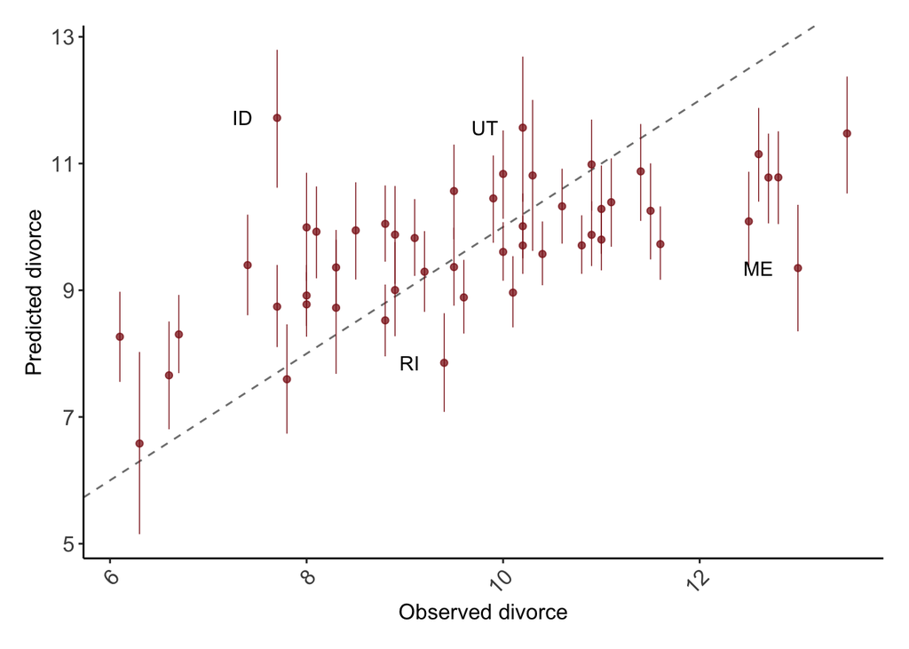

```r
fitted(fit_mlr) %>%
  data.frame() %>%
  mutate_all(~. * sd(d$Divorce) + mean(d$Divorce)) %>%
  bind_cols(d) %>%

  ggplot(aes(x = Divorce, y = Estimate)) +
  geom_abline(linetype = 2, color = "grey50", size = .5) +
  geom_point(size = 1.5, color = "firebrick4", alpha = 3/4) +
  geom_linerange(aes(ymin = Q2.5, ymax = Q97.5),
                 size = 1/4, color = "firebrick4") +
  geom_text(data = . %>% filter(Loc %in% c("ID", "UT", "RI", "ME")),
            aes(label = Loc),
            hjust = 1, nudge_x = - 0.25) +
  labs(x = "Observed divorce", y = "Predicted divorce") +
  theme_plots() +
  theme(panel.grid = element_blank())
```

Like in the book chapter the logically occurring under-predictions for states with very high divorce rates and the over-predictions for states with very low divorce rates resulting from the regressions divergence towards the mean remain. Yet, it appears as if some of the predictions are slightly less further away from the mean after the inclusion of S (e. g. mean prediction for Idaho now below 12%).

Similar to the previous regressions, we can also display the coefficients of the MLR in a plot:

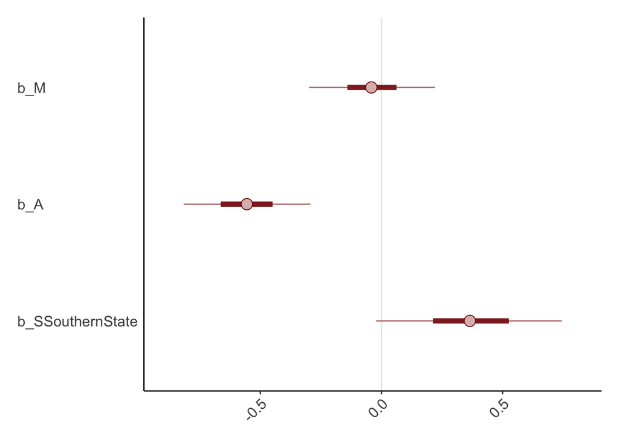

```r
post_mlr <- posterior_samples(fit_mlr)

color_scheme_set("red")

post_mlr %>%
  select(b_M:b_SSouthernState) %>%
  mcmc_intervals(prob = .5,
                 point_est = "median") +
  theme_plots() +
  theme(axis.text.y = element_text(hjust = 0),
        axis.ticks.y = element_blank(),
        panel.grid = element_blank())
```

The results show us that the coefficients for the two predictors marriage rate and median age at marriage remain relatively unchanged when we compare them with the results from the book chapter in which state type was not considered. For the newly included state type, on the other hand, we observe that divorce rates are relatively higher in Southern states than in non-Southern states (also when the model knows about the other two variables). The model estimate a positive deviation of 0.36 SD with 95% credible intervals [-0.11, 0.82] for Southern states as compared to the rates in non-Southern states.

Returning to the initial ideas presented in the second DAG, these results are frankly difficult to explain by religious beliefs alone. One could argue that earlier marriage in a relationship is not exclusive to younger people in the South and therefore more people are divorced later. However, the estimate seems so large that there are likely more unobserved effects associated with state type.